# Predicción de series temporales

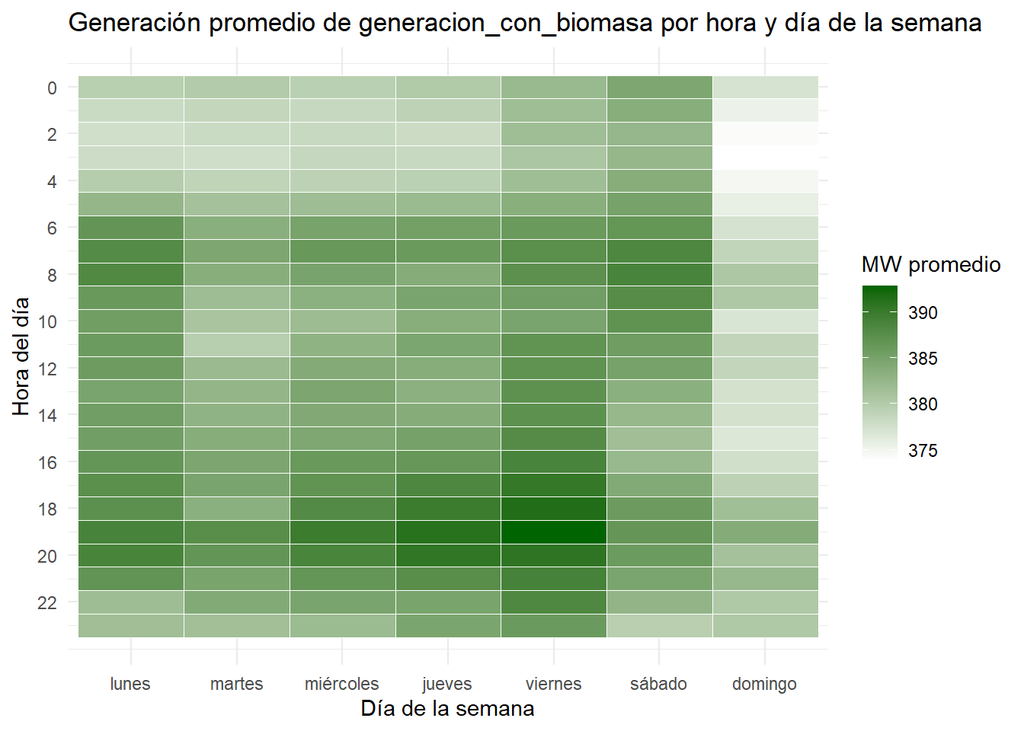

```
## Presiona Enter para ver el siguiente heatmap...
```

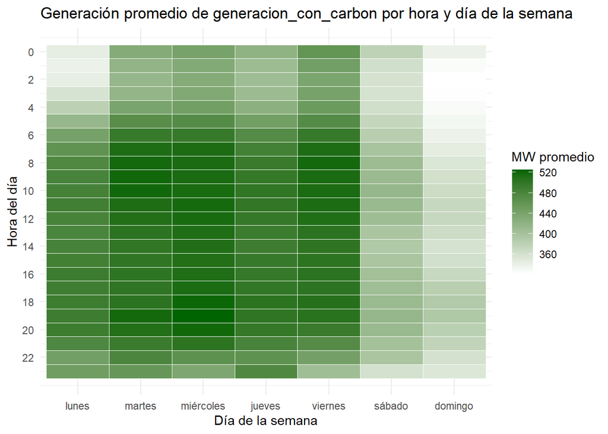

```
## Presiona Enter para ver el siguiente heatmap...
```

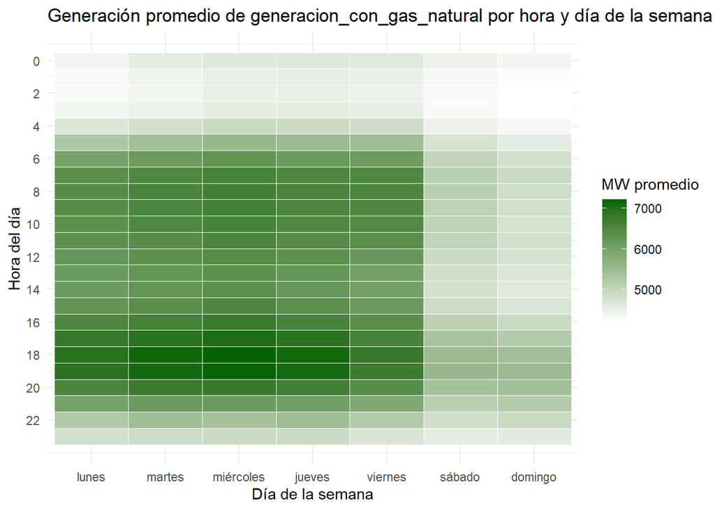

```
## Presiona Enter para ver el siguiente heatmap...
```

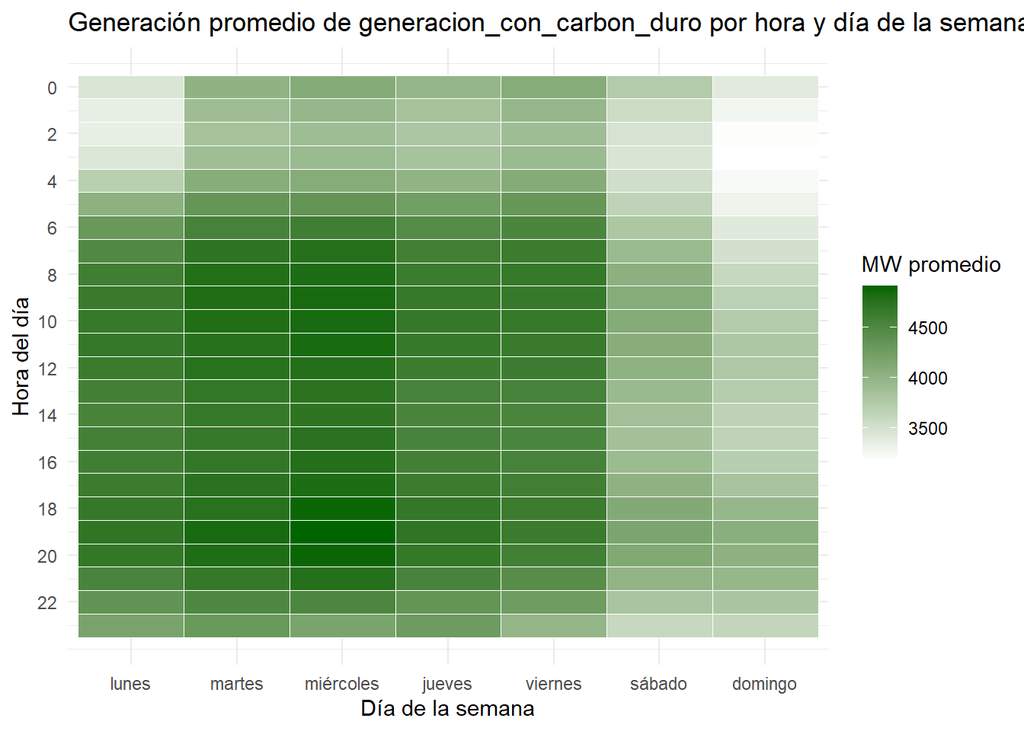

```
## Presiona Enter para ver el siguiente heatmap...
```

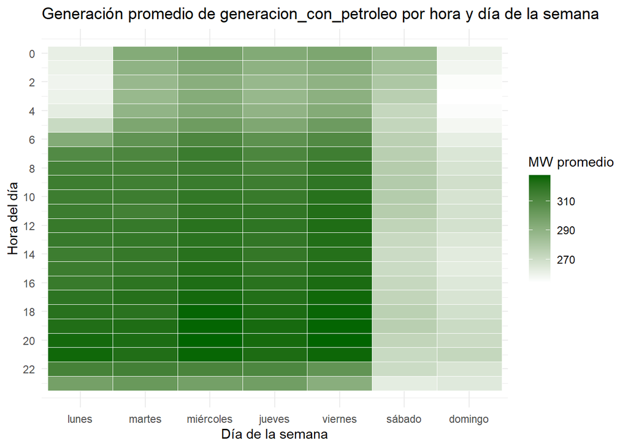

```
## Presiona Enter para ver el siguiente heatmap...
```

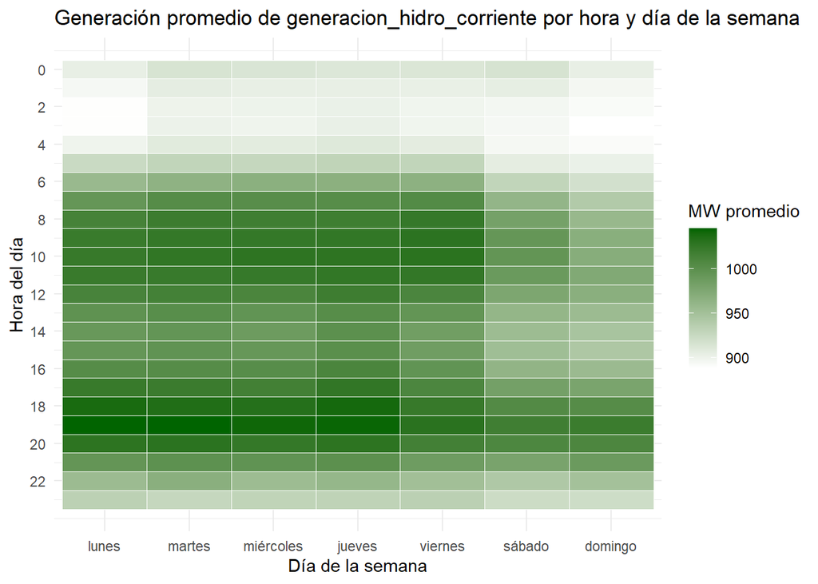

```
## Presiona Enter para ver el siguiente heatmap...
```

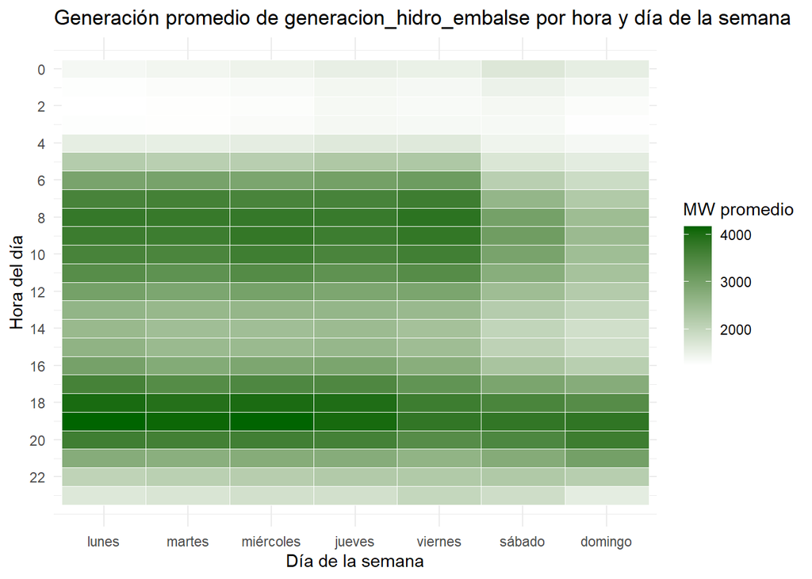

```
## Presiona Enter para ver el siguiente heatmap...
```

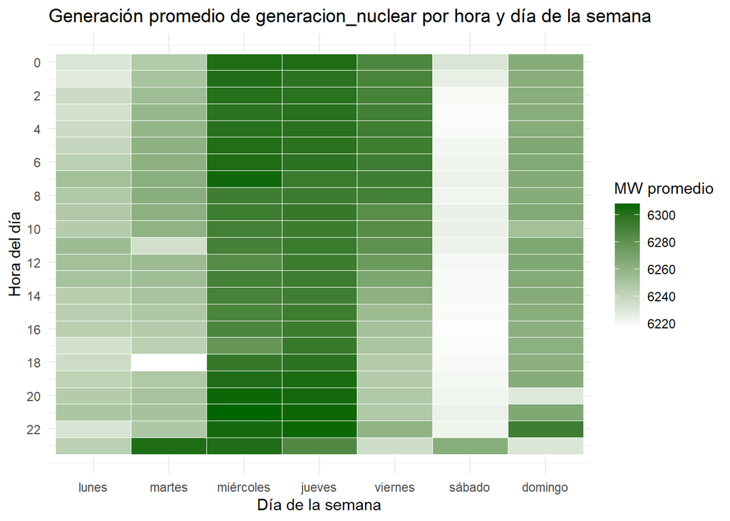

```
## Presiona Enter para ver el siguiente heatmap...
```

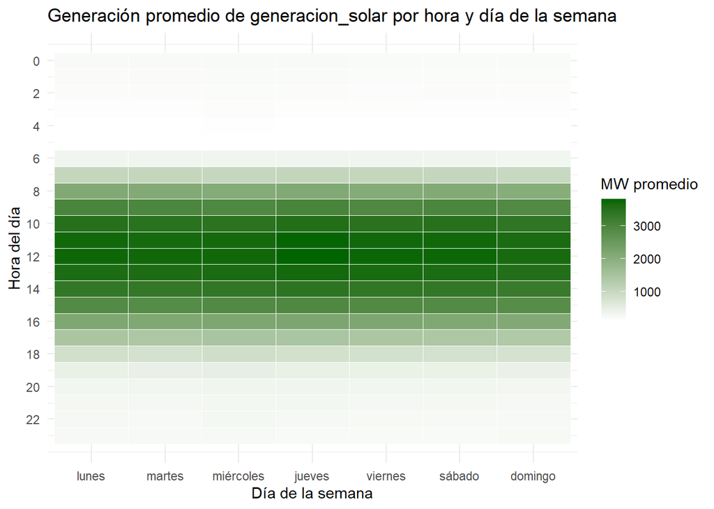

```
## Presiona Enter para ver el siguiente heatmap...
```

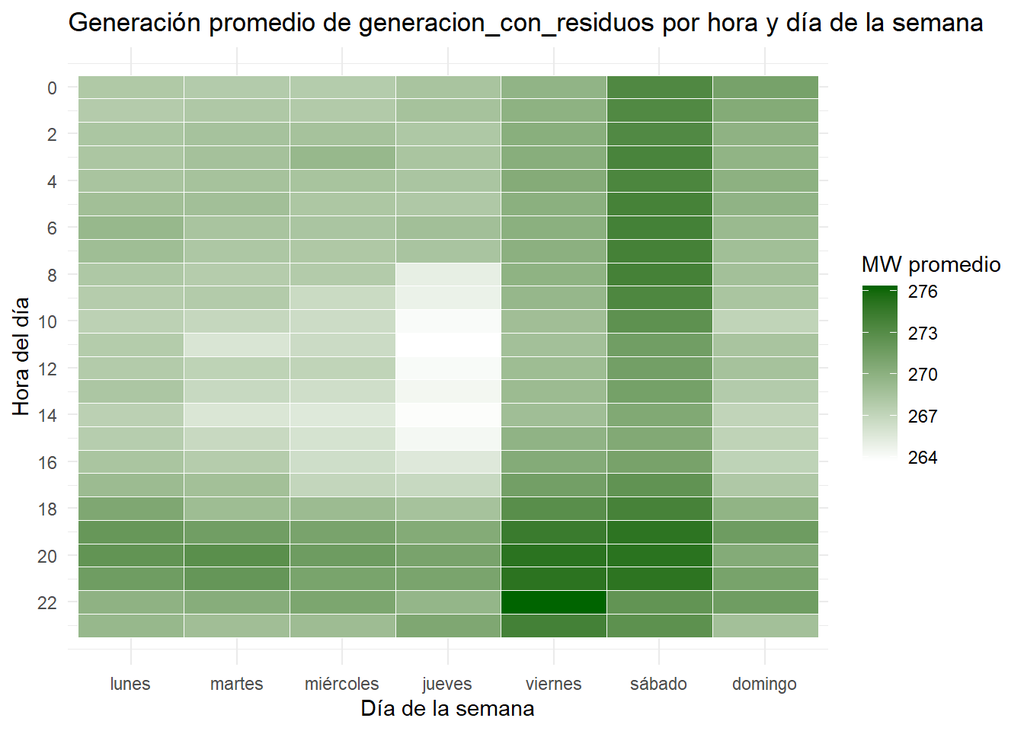

```
## Presiona Enter para ver el siguiente heatmap...
```

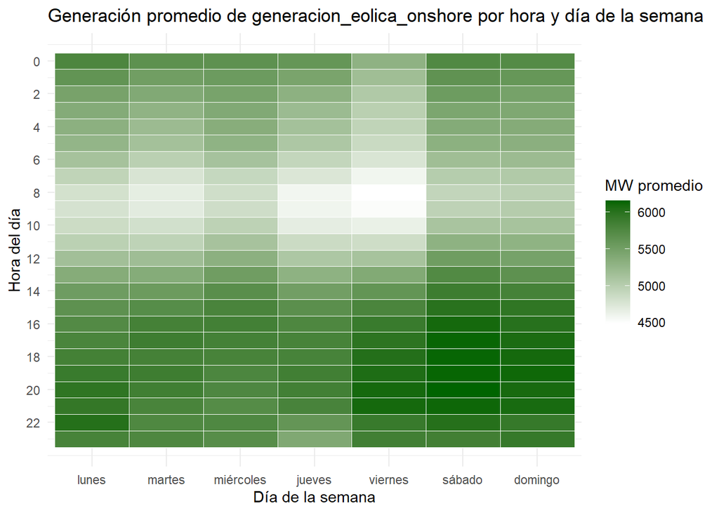

```
## Presiona Enter para ver el siguiente heatmap...
```

```r
fuentes <- c("generacion_con_biomasa", "generacion_con_carbon", "generacion_con_gas_natural",
             "generacion_con_carbon_duro", "generacion_con_petroleo",
             "generacion_hidro_corriente", "generacion_hidro_embalse", "generacion_nuclear",
             "generacion_solar", "generacion_con_residuos", "generacion_eolica_onshore")

# Asegúrate que datetime está en formato POSIXct
df_limpio <- df_limpio %>%
  mutate(datetime = as.POSIXct(datetime),
         hora_num = hour(datetime),
         dia_semana = factor(dia_semana,
                             levels = c("lunes", "martes", "miércoles", "jueves", "viernes", "sábado", "domingo")))

for (fuente in fuentes) {
  # Crear tabla resumen promedio por hora y día para la fuente actual
  heatmap_data <- df_limpio %>%
    group_by(hora_num, dia_semana) %>%
    summarise(promedio_generacion = mean(.data[[fuente]], na.rm = TRUE)) %>%
    ungroup()

  # Graficar heatmap
  p <- ggplot(heatmap_data, aes(x = dia_semana, y = hora_num, fill = promedio_generacion)) +
    geom_tile(color = "white") +
    scale_fill_gradient(low = "white", high = "darkgreen") +
    labs(title = paste("Generación promedio de", fuente, "por hora y día de la semana"),
         x = "Día de la semana",
         y = "Hora del día",
         fill = "MW promedio") +
    scale_y_reverse(breaks = seq(0,23, by=2)) +  # Invertir eje Y para que 0 esté arriba
    theme_minimal()

  print(p)

  cat("Presiona Enter para ver el siguiente heatmap...")
  invisible(readline())
}
```

Se analizan demanda y precio con gráficos similares.

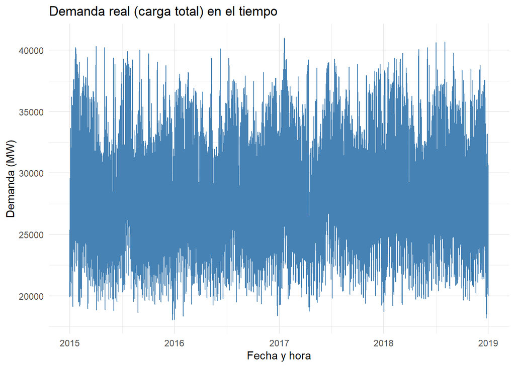

```r
library(dplyr)
library(lubridate)

df_limpio <- df_limpio %>%
  mutate(datetime = lubridate::dmy_hm(paste(fecha, hora)),
         dia_semana = factor(dia_semana, levels = c("lunes", "martes", "miércoles", "jueves", "viernes", "sábado", "domingo")),
         mes = factor(mes, levels = tolower(month.name)),
         hora_num = hour(datetime))


library(ggplot2)

ggplot(df_limpio, aes(x = datetime, y = carga_total_real)) +
  geom_line(color = "steelblue") +
  labs(title = "Demanda real (carga total) en el tiempo",
       x = "Fecha y hora",
       y = "Demanda (MW)") +
  theme_minimal()
```

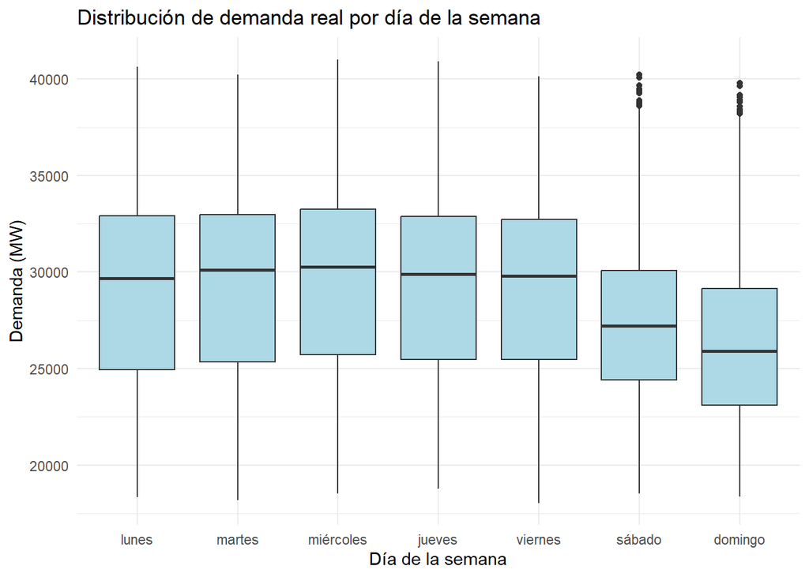

```r
ggplot(df_limpio, aes(x = dia_semana, y = carga_total_real)) +
  geom_boxplot(fill = "lightblue") +
  labs(title = "Distribución de demanda real por día de la semana",
       x = "Día de la semana",
       y = "Demanda (MW)") +
  theme_minimal()
```

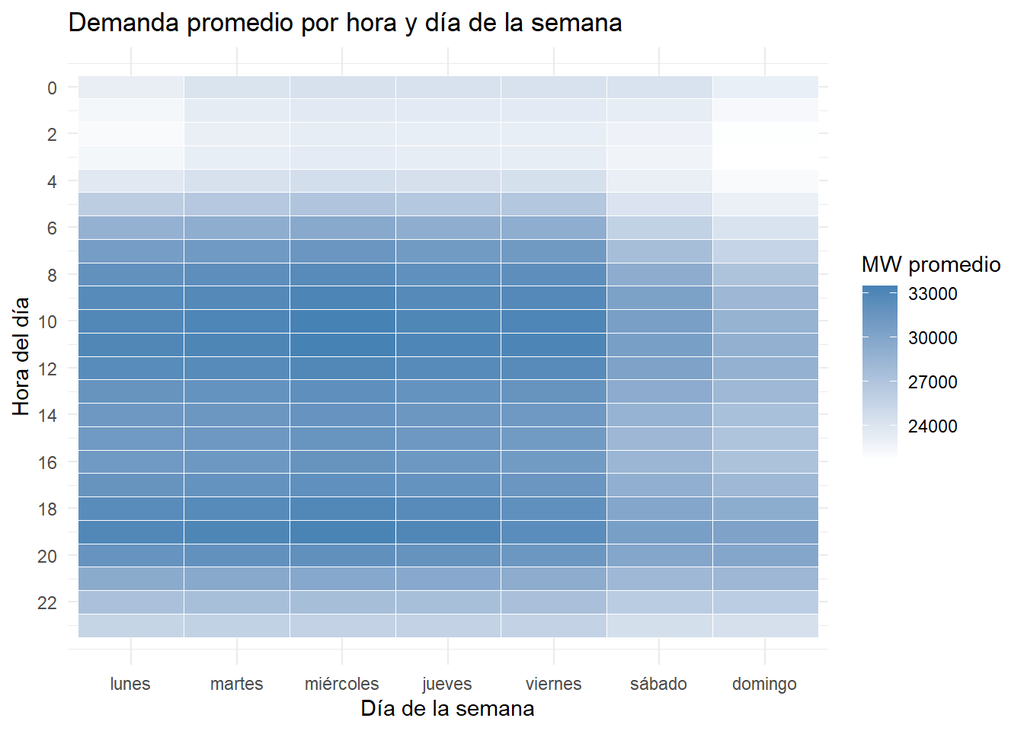

```r
heatmap_data <- df_limpio %>%
  group_by(hora_num, dia_semana) %>%
  summarise(promedio_demanda = mean(carga_total_real, na.rm = TRUE)) %>%
  ungroup()
ggplot(heatmap_data, aes(x = dia_semana, y = hora_num, fill = promedio_demanda)) +
  geom_tile(color = "white") +
  scale_fill_gradient(low = "white", high = "steelblue") +
  labs(title = "Demanda promedio por hora y día de la semana",
       x = "Día de la semana",
       y = "Hora del día",
       fill = "MW promedio") +
  scale_y_reverse(breaks = seq(0,23, by=2)) +
  theme_minimal()
```

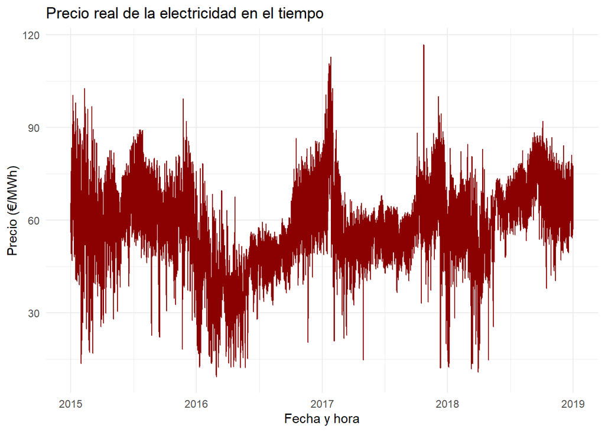

```r
library(ggplot2)

ggplot(df_limpio, aes(x = datetime, y = precio_real)) +
  geom_line(color = "darkred") +
  labs(title = "Precio real de la electricidad en el tiempo",
       x = "Fecha y hora",
       y = "Precio (€/MWh)") +
  theme_minimal()
```

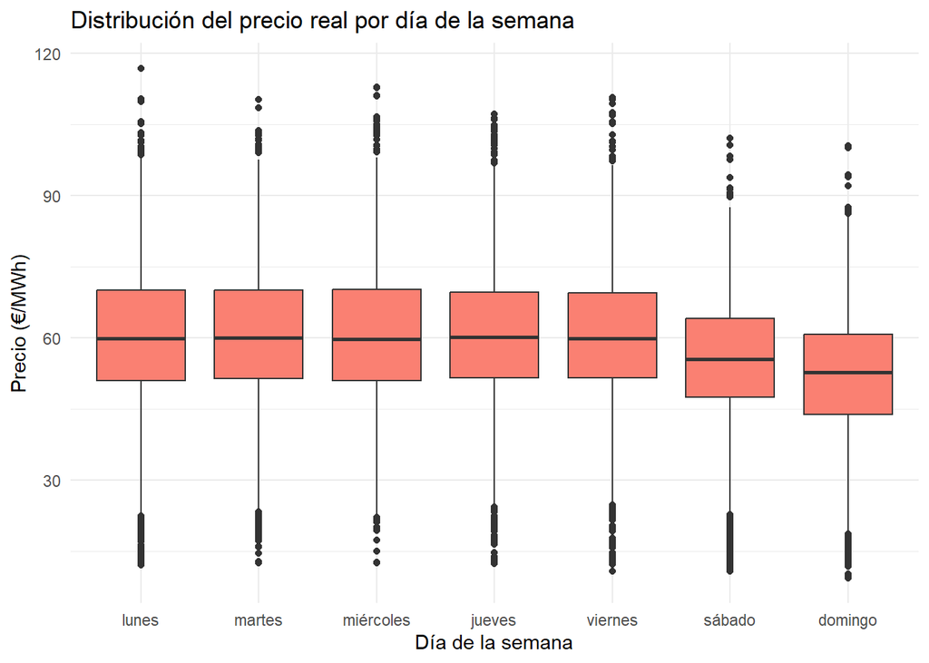

```r
ggplot(df_limpio, aes(x = dia_semana, y = precio_real)) +
  geom_boxplot(fill = "salmon") +
  labs(title = "Distribución del precio real por día de la semana",
       x = "Día de la semana",
       y = "Precio (€/MWh)") +
  theme_minimal()
```

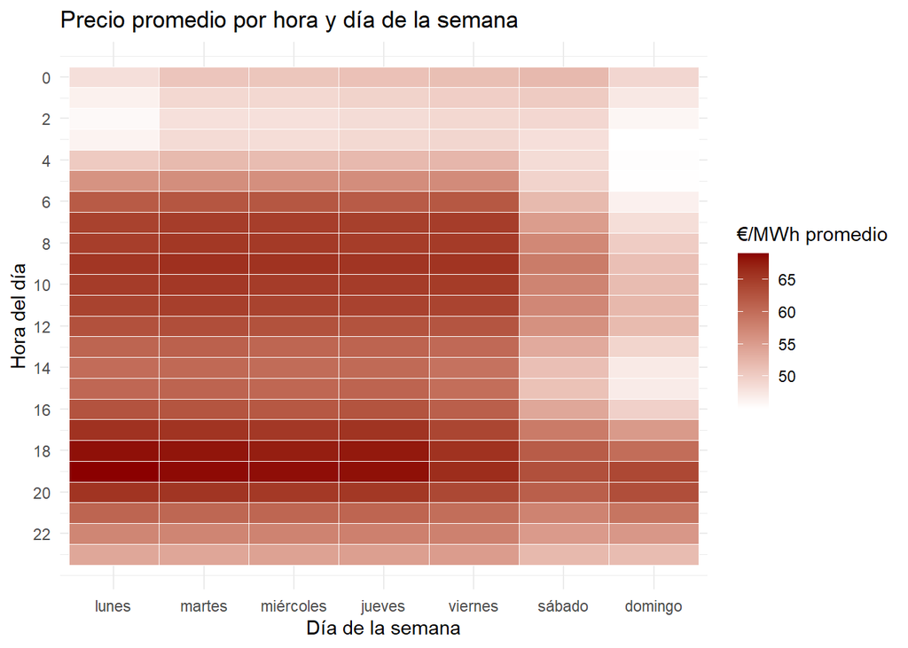

```r
heatmap_data <- df_limpio %>%
  group_by(hora_num, dia_semana) %>%
  summarise(promedio_precio = mean(precio_real, na.rm = TRUE)) %>%
  ungroup()
ggplot(heatmap_data, aes(x = dia_semana, y = hora_num, fill = promedio_precio)) +
  geom_tile(color = "white") +
  scale_fill_gradient(low = "white", high = "darkred") +
  labs(title = "Precio promedio por hora y día de la semana",
       x = "Día de la semana",
       y = "Hora del día",
       fill = "€/MWh promedio") +
  scale_y_reverse(breaks = seq(0,23, by=2)) +
  theme_minimal()
```

Se comparan demanda real vs pronosticada

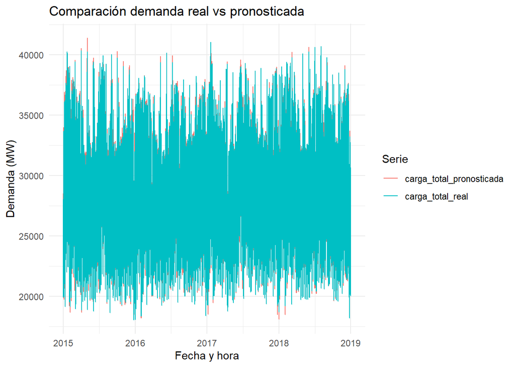

```r
library(ggplot2)
library(dplyr)
library(tidyr)

df_comparacion <- df_limpio %>%
  select(datetime, carga_total_real, carga_total_pronosticada) %>%
  pivot_longer(cols = c(carga_total_real, carga_total_pronosticada),
               names_to = "tipo", values_to = "demanda")

ggplot(df_comparacion, aes(x = datetime, y = demanda, color = tipo)) +
  geom_line() +
  labs(title = "Comparación demanda real vs pronosticada",
       x = "Fecha y hora",
       y = "Demanda (MW)",
       color = "Serie") +
  theme_minimal()
```

Se calculan métricas de error (MAE, MSE, RMSE, MAPE)

```r
library(Metrics)  # o puedes definir funciones manualmente
```

```r
mae_val <- mae(df_limpio$carga_total_real, df_limpio$carga_total_pronosticada)
mse_val <- mse(df_limpio$carga_total_real, df_limpio$carga_total_pronosticada)
rmse_val <- rmse(df_limpio$carga_total_real, df_limpio$carga_total_pronosticada)
mape_val <- mean(abs((df_limpio$carga_total_real - df_limpio$carga_total_pronosticada) / df_limpio$carga_total_real)) * 100

cat("MAE:", mae_val, "\nMSE:", mse_val, "\nRMSE:", rmse_val, "\nMAPE (%):", mape_val)
```

```
## MAE: 320.6774
## MSE: 235972.6
## RMSE: 485.7701
## MAPE (%): 1.111936
```

### Relación entre generación, demanda y precios

**PRECIO REAL VS VARIABLES CONSIDERADAS INDEPENDIENTES**

```r
modelo <- lm(precio_real ~ carga_total_real + generacion_con_biomasa + generacion_con_carbon + generacion_con_gas_natural + generacion_con_carbon_duro + generacion_con_petroleo + generacion_hidro_embalse + generacion_nuclear + otras + renovables_otras + generacion_con_residuos + generacion_hidro_corriente + generacion_solar + generacion_eolica_onshore, data = df_limpio)
summary(modelo)
```

```
##
## Call:
## lm(formula = precio_real ~ carga_total_real + generacion_con_biomasa +
##     generacion_con_carbon + generacion_con_gas_natural + generacion_con_carbon_duro +
##     generacion_con_petroleo + generacion_hidro_embalse + generacion_nuclear +
##     otras + renovables_otras + generacion_con_residuos + generacion_hidro_corriente +
##     generacion_solar + generacion_eolica_onshore, data = df_limpio)
##
## Residuals:
##     Min      1Q  Median      3Q     Max
## -50.285  -6.644   0.349   6.954  51.894
##
## Coefficients:
##                              Estimate Std. Error t value Pr(>|t|)
## (Intercept)                -3.753e+00  1.021e+00  -3.675 0.000238 ***
## carga_total_real            7.732e-04  3.792e-05  20.391  < 2e-16 ***
## generacion_con_biomasa      2.595e-02  1.223e-03  21.211  < 2e-16 ***
## generacion_con_carbon      -9.218e-04  2.900e-04  -3.179 0.001481 **
## generacion_con_gas_natural  7.072e-04  4.973e-05  14.221  < 2e-16 ***
## generacion_con_carbon_duro  1.873e-03  6.761e-05  27.708  < 2e-16 ***
## generacion_con_petroleo    -1.075e-02  1.582e-03  -6.795 1.10e-11 ***
## generacion_hidro_embalse   -1.012e-04  6.811e-05  -1.486 0.137285
## generacion_nuclear         -4.540e-04  8.115e-05  -5.594 2.23e-08 ***
## otras                       3.779e-02  4.125e-03   9.161  < 2e-16 ***
## renovables_otras            3.097e-01  6.976e-03  44.390  < 2e-16 ***
## generacion_con_residuos    -1.291e-02  1.781e-03  -7.245 4.43e-13 ***
## generacion_hidro_corriente  5.313e-04  2.638e-04   2.014 0.044018 *
## generacion_solar           -2.467e-04  5.261e-05  -4.690 2.75e-06 ***
## generacion_eolica_onshore  -2.204e-04  3.414e-05  -6.456 1.09e-10 ***
## ---
## Signif. codes:  0 '***' 0.001 '**' 0.01 '*' 0.05 '.' 0.1 ' ' 1
##
## Residual standard error: 11.32 on 35049 degrees of freedom
## Multiple R-squared:  0.3646, Adjusted R-squared:  0.3644
## F-statistic:  1437 on 14 and 35049 DF,  p-value: < 2.2e-16
```

**Interpretación:**

carga_total_real (demanda real): coeficiente positivo (0.0007732), indica que a mayor demanda, mayor precio, lo esperado por la ley de oferta y demanda.

generacion_con_biomasa, generacion_con_gas_natural,generacion_con_carbon_duro, otras, renovables_otras, generacion_hidro_corriente: coeficientes positivos y significativos, sugiriendo que un aumento en estas fuentes está asociado a un aumento en el precio.

En particular, renovables_otras tiene un coeficiente alto (0.3097), indicando un impacto fuerte en el precio.

- Variables con efecto negativo significativo:

generacion_con_carbon, generacion_con_petroleo, generacion_nuclear, generacion_con_residuos, generacion_solar, generacion_eolica_onshore: coeficientes negativos y significativos, lo que indica que un aumento en estas fuentes tiende a reducir el precio.

Esto puede reflejar que estas fuentes, especialmente las renovables como solar y eólica, al aumentar la oferta, presionan a la baja el precio.

**DEMANDA VS VARIABLES CONSIDERADAS INDEPENDIENTES**

```r
modelo <- lm(carga_total_real ~ precio_real + generacion_con_biomasa + generacion_con_carbon + generacion_con_gas_natural + generacion_con_carbon_duro + generacion_con_petroleo + generacion_hidro_embalse + generacion_nuclear + otras + renovables_otras + generacion_con_residuos + generacion_hidro_corriente + generacion_solar + generacion_eolica_onshore, data = df_limpio)
summary(modelo)
```

```
##
## Call:
## lm(formula = carga_total_real ~ precio_real + generacion_con_biomasa +
##     generacion_con_carbon + generacion_con_gas_natural + generacion_con_carbon_duro +
##     generacion_con_petroleo + generacion_hidro_embalse + generacion_nuclear +
##     otras + renovables_otras + generacion_con_residuos + generacion_hidro_corriente +
##     generacion_solar + generacion_eolica_onshore, data = df_limpio)
##
## Residuals:
##    Min     1Q Median     3Q    Max
##  -8959  -1019     20   1050  33045
##
## Coefficients:
##                              Estimate Std. Error t value Pr(>|t|)
## (Intercept)                -2.764e+03  1.423e+02 -19.427  < 2e-16 ***
## precio_real                 1.516e+01  7.437e-01  20.391  < 2e-16 ***
## generacion_con_biomasa      1.562e+00  1.722e-01   9.069  < 2e-16 ***
## generacion_con_carbon       7.519e-01  4.042e-02  18.600  < 2e-16 ***
## generacion_con_gas_natural  7.617e-01  5.676e-03 134.189  < 2e-16 ***
## generacion_con_carbon_duro  8.089e-01  8.540e-03  94.718  < 2e-16 ***
## generacion_con_petroleo     1.121e+01  2.135e-01  52.527  < 2e-16 ***
## generacion_hidro_embalse    1.209e+00  7.019e-03 172.277  < 2e-16 ***
## generacion_nuclear          7.840e-01  1.057e-02  74.165  < 2e-16 ***
## otras                      -2.867e+00  5.782e-01  -4.958 7.16e-07 ***
## renovables_otras            3.998e+01  9.811e-01  40.746  < 2e-16 ***
## generacion_con_residuos     6.444e+00  2.473e-01  26.056  < 2e-16 ***
## generacion_hidro_corriente  5.105e-01  3.685e-02  13.855  < 2e-16 ***
## generacion_solar            9.807e-01  5.185e-03 189.142  < 2e-16 ***
## generacion_eolica_onshore   6.638e-01  3.212e-03 206.666  < 2e-16 ***
## ---
## Signif. codes:  0 '***' 0.001 '**' 0.01 '*' 0.05 '.' 0.1 ' ' 1
##
## Residual standard error: 1586 on 35049 degrees of freedom
## Multiple R-squared:  0.8798, Adjusted R-squared:  0.8797
## F-statistic: 1.832e+04 on 14 and 35049 DF,  p-value: < 2.2e-16
```

**Interpretación**

- Intercepto (-2764): Cuando todas las variables explicativas son cero, la carga total real se estima en -2764 (valor teórico, puede no tener sentido físico si las variables no pueden ser cero).
- precio_real (15.16): Por cada unidad que aumenta el precio real, la carga total real aumenta en 15.16 unidades, manteniendo todo lo demás constante. Esto puede indicar que la demanda aumenta con el precio, lo cual es poco común y podría requerir análisis adicional (posible colinealidad o efecto de variables omitidas).
- generacion_con_biomasa (1.56): Cada unidad adicional de generación con biomasa incrementa la carga total real en 1.56 unidades.
- generacion_con_carbon (0.75), generacion_con_gas_natural (0.76), generacion_con_carbon_duro (0.81), generacion_con_petroleo (11.21),- generacion_hidro_embalse (1.21), generacion_nuclear (0.78), generacion_con_residuos (6.44), generacion_hidro_corriente (0.51), generacion_solar (0.98), generacion_eolica_onshore (0.66): Todas estas fuentes de generación tienen coeficientes positivos y altamente significativos, indicando que a mayor generación en estas fuentes, mayor es la carga total real.
- otras (-2.87): Esta variable tiene un coeficiente negativo significativo, lo que indica que un aumento en “otras” fuentes está asociado con una disminución en la carga total real.
- renovables_otras (39.98): Tiene el coeficiente más alto, indicando que un aumento en esta categoría de renovables tiene un gran impacto positivo en la carga total real.

### Detectamos picos y factores que generan caidas de demanda

```r
library(dplyr)
library(lubridate)

df_limpio <- df_limpio %>%
  mutate(
    fecha_hora = dmy_hm(paste(fecha, hora))
  )


# Calcular z-score de la demanda
df_limpio <- df_limpio %>%
  mutate(
    z_score_demanda = (carga_total_real - mean(carga_total_real)) / sd(carga_total_real)
  )

# Definir umbrales para picos y caídas (por ejemplo, ±2 desviaciones estándar)
picos <- filter(df_limpio, z_score_demanda > 2)
caidas <- filter(df_limpio, z_score_demanda < -2)
```

Picos:

```r
summary(picos %>% select(precio_real, starts_with("generacion_")))
```

```
##   precio_real     generacion_con_biomasa generacion_con_carbon
##  Min.   : 32.00   Min.   :263.0          Min.   :  0.0
##  1st Qu.: 64.62   1st Qu.:350.0          1st Qu.:637.0
##  Median : 72.96   Median :379.0          Median :780.0
##  Mean   : 75.19   Mean   :409.4          Mean   :715.8
##  3rd Qu.: 85.41   3rd Qu.:492.0          3rd Qu.:948.0
##  Max.   :112.81   Max.   :567.0          Max.   :995.0
##  generacion_con_gas_natural generacion_con_carbon_duro generacion_con_petroleo
##  Min.   :    0              Min.   :1619               Min.   :268.0
##  1st Qu.: 7187              1st Qu.:5922               1st Qu.:308.0
##  Median : 9284              Median :6704               Median :338.0
##  Mean   : 9275              Mean   :6618               Mean   :340.4
##  3rd Qu.:10849              3rd Qu.:7572               3rd Qu.:365.0
##  Max.   :20034              Max.   :8359               Max.   :427.0
##  generacion_hidro_corriente generacion_hidro_embalse generacion_nuclear
##  Min.   : 524.0             Min.   : 614             Min.   :5044
##  1st Qu.: 739.0             1st Qu.:3092             1st Qu.:6095
##  Median : 963.0             Median :4168             Median :6934
##  Mean   : 997.5             Mean   :4225             Mean   :6706
##  3rd Qu.:1246.0             3rd Qu.:5271             3rd Qu.:7104
##  Max.   :1768.0             Max.   :9056             Max.   :7114
##  generacion_solar generacion_con_residuos generacion_eolica_onshore
##  Min.   :  10     Min.   :147.0           Min.   :  303
##  1st Qu.: 143     1st Qu.:249.0           1st Qu.: 3107
##  Median :1657     Median :289.0           Median : 5509
##  Mean   :2253     Mean   :278.2           Mean   : 5962
##  3rd Qu.:4507     3rd Qu.:311.0           3rd Qu.: 8421
##  Max.   :5360     Max.   :345.0           Max.   :17436
```

Caidas:

```r
summary(caidas %>% select(precio_real, starts_with("generacion_")))
```

```
##   precio_real    generacion_con_biomasa generacion_con_carbon
##  Min.   :15.80   Min.   :226.0          Min.   :  0.0
##  1st Qu.:38.36   1st Qu.:285.0          1st Qu.:  0.0
##  Median :49.10   Median :322.0          Median :  0.0
##  Mean   :45.58   Mean   :333.7          Mean   :203.1
##  3rd Qu.:54.58   3rd Qu.:359.0          3rd Qu.:375.0
##  Max.   :71.02   Max.   :564.0          Max.   :950.0
##  generacion_con_gas_natural generacion_con_carbon_duro generacion_con_petroleo
##  Min.   :3008               Min.   : 609               Min.   :122.0
##  1st Qu.:3717               1st Qu.:1138               1st Qu.:191.0
##  Median :4009               Median :1682               Median :216.0
##  Mean   :4093               Mean   :2055               Mean   :217.4
##  3rd Qu.:4395               3rd Qu.:2545               3rd Qu.:239.0
##  Max.   :5529               Max.   :5252               Max.   :317.0
##  generacion_hidro_corriente generacion_hidro_embalse generacion_nuclear
##  Min.   : 314.0             Min.   : 172             Min.   :3939
##  1st Qu.: 519.0             1st Qu.: 442             1st Qu.:5747
##  Median : 914.0             Median : 699             Median :7051
##  Mean   : 860.6             Mean   :1044             Mean   :6419
##  3rd Qu.:1149.0             3rd Qu.:1150             3rd Qu.:7092
##  Max.   :1751.0             Max.   :5709             Max.   :7111
##  generacion_solar  generacion_con_residuos generacion_eolica_onshore
##  Min.   :   4.00   Min.   : 85.0           Min.   : 1158
##  1st Qu.:  20.00   1st Qu.:165.0           1st Qu.: 3392
##  Median :  33.00   Median :250.0           Median : 5293
##  Mean   :  84.05   Mean   :230.4           Mean   : 5204
##  3rd Qu.:  83.00   3rd Qu.:282.0           3rd Qu.: 6620
##  Max.   :1567.00   Max.   :334.0           Max.   :11012
```

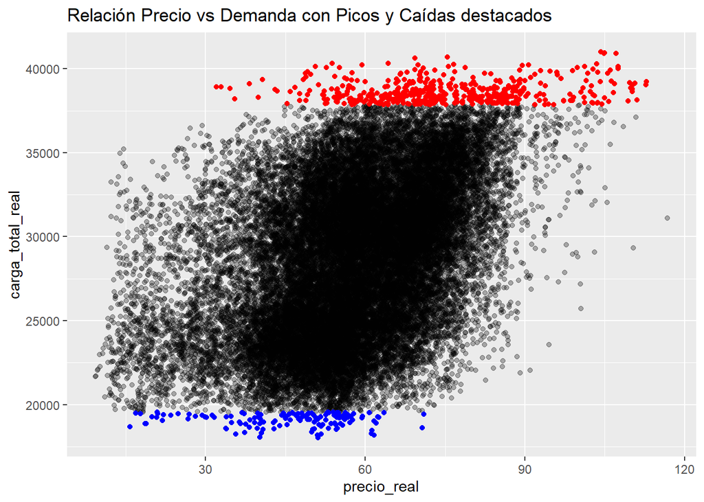

```r
ggplot(df_limpio, aes(x = precio_real, y = carga_total_real)) +
  geom_point(alpha = 0.3) +
  geom_point(data = picos, aes(x = precio_real, y = carga_total_real), color = "red") +
  geom_point(data = caidas, aes(x = precio_real, y = carga_total_real), color = "blue") +
  labs(title = "Relación Precio vs Demanda con Picos y Caídas destacados")
```

Caidas:

```r
df_limpio <- df_limpio %>%
  mutate(
    evento_demanda = case_when(
      z_score_demanda > 2 ~ "pico",
      z_score_demanda < -2 ~ "caida",
      TRUE ~ "normal"
    )
  )

# Modelo para predecir caidas (binario)
df_limpio$pico_bin <- ifelse(df_limpio$evento_demanda == "caida", 1, 0)

modelo_picos <- glm(pico_bin ~ precio_real + generacion_con_biomasa + generacion_con_carbon + generacion_con_gas_natural + generacion_con_carbon_duro + generacion_con_petroleo + generacion_hidro_embalse + generacion_nuclear + otras + renovables_otras + generacion_con_residuos + generacion_hidro_corriente + generacion_solar + generacion_eolica_onshore, data = df_limpio, family = binomial)
summary(modelo_picos)
```

```
##
## Call:
## glm(formula = pico_bin ~ precio_real + generacion_con_biomasa +
##     generacion_con_carbon + generacion_con_gas_natural + generacion_con_carbon_duro +
##     generacion_con_petroleo + generacion_hidro_embalse + generacion_nuclear +
##     otras + renovables_otras + generacion_con_residuos + generacion_hidro_corriente +
##     generacion_solar + generacion_eolica_onshore, family = binomial,
##     data = df_limpio)
##
## Coefficients:
##                              Estimate Std. Error z value Pr(>|z|)
## (Intercept)                 2.113e+01  2.223e+00   9.508  < 2e-16 ***
## precio_real                -4.091e-03  9.630e-03  -0.425   0.6710
## generacion_con_biomasa      1.937e-03  2.107e-03   0.919   0.3579
## generacion_con_carbon       1.364e-03  5.824e-04   2.342   0.0192 *
## generacion_con_gas_natural -1.513e-03  2.251e-04  -6.720 1.82e-11 ***
## generacion_con_carbon_duro -1.533e-03  1.577e-04  -9.716  < 2e-16 ***
## generacion_con_petroleo    -1.357e-02  2.815e-03  -4.822 1.42e-06 ***
## generacion_hidro_embalse   -1.661e-03  1.915e-04  -8.672  < 2e-16 ***
## generacion_nuclear         -1.882e-04  1.520e-04  -1.238   0.2156
## otras                      -1.691e-02  6.039e-03  -2.801   0.0051 **
## renovables_otras           -1.735e-02  1.117e-02  -1.553   0.1205
## generacion_con_residuos    -1.162e-02  2.403e-03  -4.837 1.32e-06 ***
## generacion_hidro_corriente  5.231e-04  4.478e-04   1.168   0.2428
## generacion_solar           -4.191e-03  7.663e-04  -5.470 4.51e-08 ***
## generacion_eolica_onshore  -6.960e-04  6.242e-05 -11.151  < 2e-16 ***
## ---
## Signif. codes:  0 '***' 0.001 '**' 0.01 '*' 0.05 '.' 0.1 ' ' 1
##
## (Dispersion parameter for binomial family taken to be 1)
##
##     Null deviance: 1792.78  on 35063  degrees of freedom
## Residual deviance:  829.32  on 35049  degrees of freedom
## AIC: 859.32
##
## Number of Fisher Scoring iterations: 13
```

- precio_real (-0.0041, p=0.671): coeficiente no significativo, no hay evidencia de que el precio afecte la probabilidad de caída.
- generacion_con_biomasa (0.0019, p=0.358): no significativo.
- generacion_con_carbon (0.00136, p=0.0192): coeficiente positivo y significativo, indica que un aumento en generación con carbón incrementa ligeramente la probabilidad de caída.
- generacion_con_gas_natural (-0.00151, p<0.001): coeficiente negativo y significativo, mayor generación con gas natural reduce la probabilidad de caída.
- generacion_con_carbon_duro (-0.00153, p<0.001): coeficiente negativo y significativo, mayor generación con carbón duro reduce la probabilidad de caída.
- generacion_con_petroleo (-0.01357, p<0.001): coeficiente negativo y significativo, mayor generación con petróleo reduce la probabilidad de caída.
- generacion_hidro_embalse (-0.00166, p<0.001): coeficiente negativo y significativo, mayor generación hidroeléctrica reduce la probabilidad de caída.
- generacion_nuclear (-0.000188, p=0.216): no significativo.
- otras (-0.0169, p=0.005): coeficiente negativo y significativo, mayor generación en “otras” reduce la probabilidad de caída.
- renovables_otras (-0.01735, p=0.120): no significativo.
- generacion_con_residuos (-0.01162, p<0.001): coeficiente negativo y significativo, mayor generación con residuos reduce la probabilidad de caída.
- generacion_hidro_corriente (0.000523, p=0.243): no significativo.
- generacion_solar (-0.00419, p<0.001): coeficiente negativo y significativo, mayor generación solar reduce la probabilidad de caída.
- generacion_eolica_onshore (-0.000696, p<0.001): coeficiente negativo y significativo, mayor generación eólica reduce la probabilidad de caída.

**Factores que las causan:**

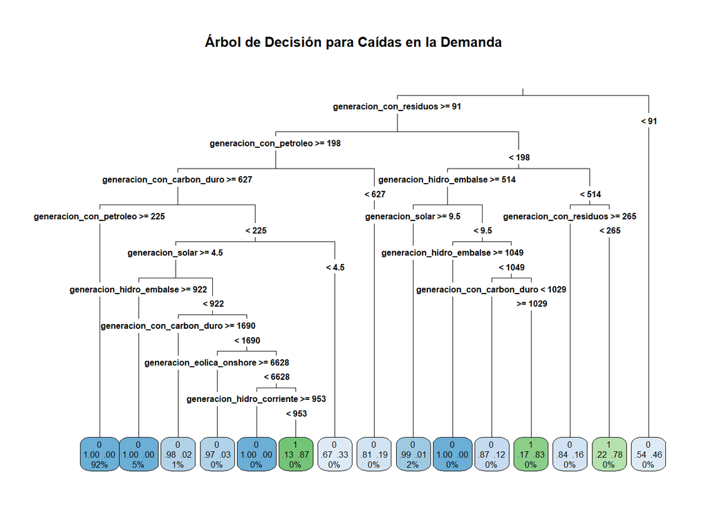

```r
library(rpart)
library(rpart.plot)


# Ajustar árbol para predecir caídas (pico_bin) con variables de generación y precio
arbol_caidas <- rpart(pico_bin ~ precio_real + generacion_con_biomasa + generacion_con_carbon + generacion_con_gas_natural + generacion_con_carbon_duro + generacion_con_petroleo + generacion_hidro_embalse + generacion_nuclear + otras + renovables_otras + generacion_con_residuos + generacion_hidro_corriente + generacion_solar + generacion_eolica_onshore,
                      data = df_limpio,
                      method = "class")

# Luego puedes graficar
rpart.plot(arbol_caidas,
           type = 3,
           extra = 104,
           fallen.leaves = TRUE,
           cex = 0.5,
           main = "Árbol de Decisión para Caídas en la Demanda")
```

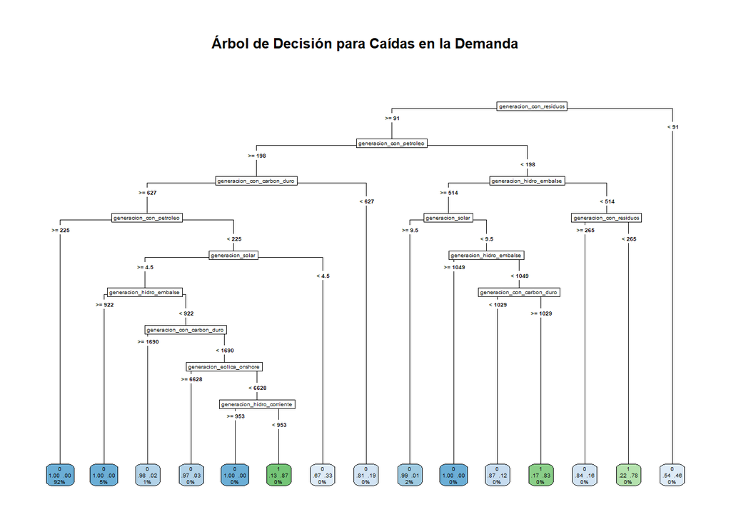

```r
rpart.plot(arbol_caidas, type = 5, extra =104, fallen.leaves = TRUE,
           main = "Árbol de Decisión para Caídas en la Demanda")
```

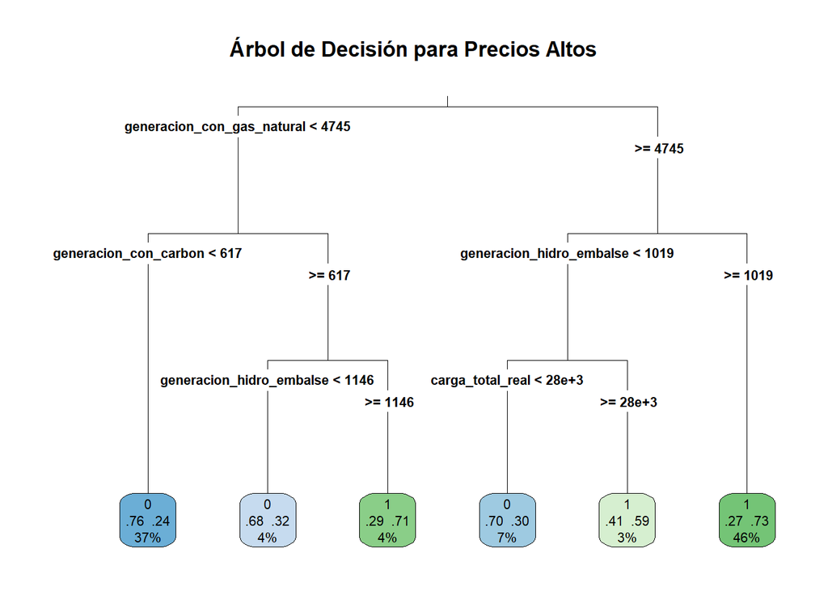

```r
df_limpio$precio_alto <- ifelse(df_limpio$precio_real > median(df_limpio$precio_real), 1, 0)

arbol_precio <- rpart(precio_alto ~ carga_total_real + generacion_con_biomasa + generacion_con_carbon +
                        generacion_con_gas_natural + generacion_con_carbon_duro + generacion_con_petroleo +
                        generacion_hidro_embalse + generacion_nuclear + otras + renovables_otras +
                        generacion_con_residuos + generacion_hidro_corriente + generacion_solar +
                        generacion_eolica_onshore,
                      data = df_limpio,
                      method = "class",
                      control = rpart.control(cp = 0.01))


rpart.plot(arbol_precio,
           type = 3,
           extra = 104,
           fallen.leaves = TRUE,
           cex = 0.7,
           main = "Árbol de Decisión para Precios Altos")
```

```r
print(arbol_precio)
```

```
## n= 35064
##
## node), split, n, loss, yval, (yprob)
##       * denotes terminal node
##
##  1) root 35064 17525 0 (0.5001996 0.4998004)
##    2) generacion_con_gas_natural< 4744.5 15467  4425 0 (0.7139070 0.2860930)
##      4) generacion_con_carbon< 616.5 12845  3078 0 (0.7603737 0.2396263) *
##      5) generacion_con_carbon>=616.5 2622  1275 1 (0.4862700 0.5137300)
##       10) generacion_hidro_embalse< 1146 1318   427 0 (0.6760243 0.3239757) *
##       11) generacion_hidro_embalse>=1146 1304   384 1 (0.2944785 0.7055215) *
##    3) generacion_con_gas_natural>=4744.5 19597  6497 1 (0.3315303 0.6684697)
##      6) generacion_hidro_embalse< 1018.5 3511  1390 0 (0.6041014 0.3958986)
##       12) carga_total_real< 28026.5 2331   688 0 (0.7048477 0.2951523) *
##       13) carga_total_real>=28026.5 1180   478 1 (0.4050847 0.5949153) *
##      7) generacion_hidro_embalse>=1018.5 16086  4376 1 (0.2720378 0.7279622) *
```

```r
summary(arbol_precio)
```

```
## Call:
## rpart(formula = precio_alto ~ carga_total_real + generacion_con_biomasa +
##     generacion_con_carbon + generacion_con_gas_natural + generacion_con_carbon_duro +
##     generacion_con_petroleo + generacion_hidro_embalse + generacion_nuclear +
##     otras + renovables_otras + generacion_con_residuos + generacion_hidro_corriente +
##     generacion_solar + generacion_eolica_onshore, data = df_limpio,
##     method = "class", control = rpart.control(cp = 0.01))
##   n= 35064
##
##           CP nsplit rel error    xerror        xstd
## 1 0.37677603      0 1.0000000 1.0097575 0.005342244
## 2 0.04171184      1 0.6232240 0.6259058 0.004954025
## 3 0.01529244      2 0.5815121 0.5884165 0.004868418
## 4 0.01278174      4 0.5509272 0.5529815 0.004778388
## 5 0.01000000      5 0.5381455 0.5434522 0.004752601
##
## Variable importance
## generacion_con_gas_natural      generacion_con_carbon
##                         29                         15
##           carga_total_real generacion_con_carbon_duro
##                         13                         13
##   generacion_hidro_embalse  generacion_eolica_onshore
##                          9                          9
##    generacion_con_petroleo generacion_hidro_corriente
##                          7                          2
##           generacion_solar                      otras
##                          2                          1
##     generacion_con_biomasa
##                          1
##
## Node number 1: 35064 observations,    complexity param=0.376776
##   predicted class=0  expected loss=0.4998004  P(node) =1
##     class counts: 17539 17525
##    probabilities: 0.500 0.500
##   left son=2 (15467 obs) right son=3 (19597 obs)
##   Primary splits:
##       generacion_con_gas_natural < 4744.5  to the left,  improve=2527.8250, (0 missing)
##       carga_total_real           < 26153.5 to the left,  improve=1954.1360, (0 missing)
##       generacion_con_carbon_duro < 4724.5  to the left,  improve=1634.0590, (0 missing)
##       generacion_con_carbon      < 605.5   to the left,  improve=1338.5290, (0 missing)
```

[output cut: 92 more lines]

```
##
## Node number 11: 1304 observations
##   predicted class=1  expected loss=0.2944785  P(node) =0.03718914
##     class counts:   384   920
##    probabilities: 0.294 0.706
##
## Node number 12: 2331 observations
##   predicted class=0  expected loss=0.2951523  P(node) =0.06647844
##     class counts:  1643   688
##    probabilities: 0.705 0.295
##
## Node number 13: 1180 observations
##   predicted class=1  expected loss=0.4050847  P(node) =0.03365275
##     class counts:   478   702
##    probabilities: 0.405 0.595
```

El árbol indica que los precios altos se asocian principalmente con:

- Alta generación con gas natural.
- Alta generación hidroeléctrica en embalse.
- Alta demanda total en ciertos contextos.
- Niveles medios o altos de generación con carbón.

Estas variables y sus umbrales son las reglas que el árbol encontró más relevantes para clasificar precios altos.

### Multicolinealidad

```r
library(car)
# Ejemplo con variables predictoras de tu dataset
modelo <- lm(carga_total_real ~ precio_real + generacion_con_biomasa + generacion_con_carbon +
               generacion_con_gas_natural + generacion_con_carbon_duro + generacion_con_petroleo +
               generacion_hidro_embalse + generacion_nuclear + otras + renovables_otras +
               generacion_con_residuos + generacion_hidro_corriente + generacion_solar +
               generacion_eolica_onshore, data = df_limpio)


vif_values <- vif(modelo)
print(vif_values)
```

```
##                precio_real     generacion_con_biomasa
##                   1.555437                   3.010107
##      generacion_con_carbon generacion_con_gas_natural
##                   2.862091                   2.176526
## generacion_con_carbon_duro    generacion_con_petroleo
##                   3.910416                   1.751019
##   generacion_hidro_embalse         generacion_nuclear
##                   2.312083                   1.097723
##                      otras           renovables_otras
##                   1.907752                   2.658032
##    generacion_con_residuos generacion_hidro_corriente
##                   2.146728                   3.038562
##           generacion_solar  generacion_eolica_onshore
##                   1.057329                   1.484390
```

Todos los VIF están por debajo de 5, lo que generalmente se considera aceptable para efectos de multicolinealidad

### ESTUDIO DE SERIES TEMPORALES

```r
serie <- ts(df_limpio$carga_total_real, start = c(2015, 1), frequency = 24*365)
```

Descomposición aditiva

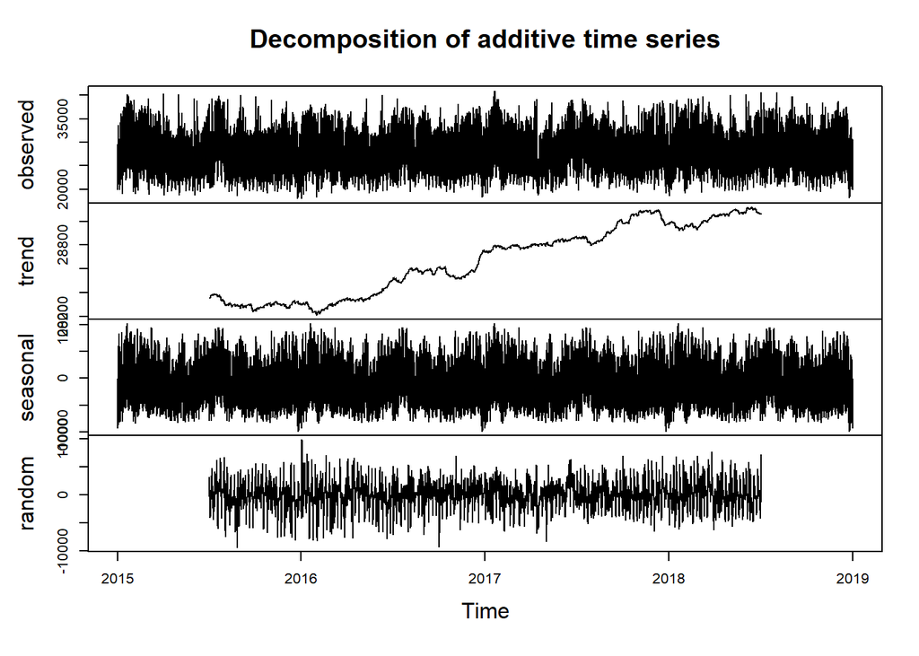

```r
descomp <- decompose(serie, type = "additive")
plot(descomp)
```

STL

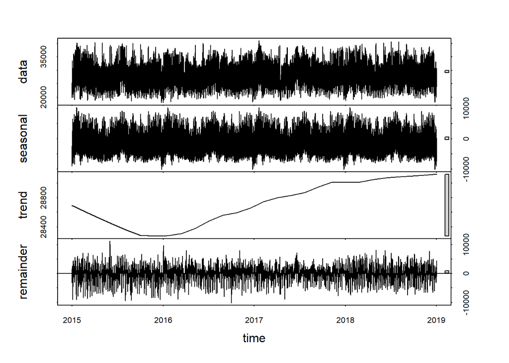

```r
library(forecast)
descomp_stl <- stl(serie, s.window = "periodic")
plot(descomp_stl)
```

```r
# Extraer componentes
tendencia <- descomp_stl$time.series[, "trend"]
estacionalidad <- descomp_stl$time.series[, "seasonal"]
ruido <- descomp_stl$time.series[, "remainder"]
```

Exploramos:

```r
# Mostrar un resumen estadístico de cada componente
summary(tendencia)
```

```
##    Min. 1st Qu.  Median    Mean 3rd Qu.    Max.
##   28272   28438   28688   28707   29012   29121
```

```r
summary(estacionalidad)
```

```
##       Min.    1st Qu.     Median       Mean    3rd Qu.       Max.
## -10093.782  -3419.003    420.867     -2.984   3062.991  10334.092
```

```r
summary(ruido)
```

```
##       Min.    1st Qu.     Median       Mean    3rd Qu.       Max.
## -10176.448  -1180.752     88.277     -7.192   1325.022  11229.498
```

- La serie de carga eléctrica tiene un componente de tendencia estable y creciente ligeramente en el rango de 28,000 a 29,000 unidades.
- Existe una estacionalidad muy marcada, con amplitudes que pueden superar las 10,000 unidades, lo que refleja patrones repetitivos diarios, semanales o anuales en la demanda eléctrica (por ejemplo, variaciones por estaciones del año, días de la semana, horas del día).
- El componente de ruido es considerable, lo que indica que hay fluctuaciones no explicadas por la tendencia ni la estacionalidad, posiblemente debidas a eventos puntuales, condiciones climáticas, o variabilidad intrínseca del sistema eléctrico.

### Modelado multivariante y causalidad

**GRANGER**

```r
library(tseries)
library(vars)
library(dplyr)
library(lmtest)

# Seleccionar variables relevantes (ajusta según tus columnas)
vars_seleccionadas <- c("carga_total_real", "precio_real",
                        "generacion_con_biomasa", "generacion_con_carbon",
                        "generacion_con_gas_natural", "generacion_con_carbon_duro",
                        "generacion_con_petroleo", "energia_consumida_bateria",
                        "generacion_hidro_corriente", "generacion_hidro_embalse",
                        "generacion_nuclear", "otras", "renovables_otras",
                        "generacion_solar", "generacion_con_residuos",
                        "generacion_eolica_onshore")
```

```r
df_var <- df_limpio %>%
  select_at(vars_seleccionadas) %>%
  na.omit()

# Convertir a serie temporal multivariada con frecuencia horaria
ts_data <- ts(df_var, frequency = 8760)
```

Verificar estacionariedad con ADF y diferenciar si es necesario

```r
adf_results <- sapply(colnames(ts_data), function(var){
  test <- adf.test(ts_data[, var])
  p_val <- test$p.value
  cat(var, "- p-valor ADF:", p_val, "\n")
  return(p_val)
})
```

```
## carga_total_real - p-valor ADF: 0.01
```

```
## precio_real - p-valor ADF: 0.01
```

```
## generacion_con_biomasa - p-valor ADF: 0.01
```

```
## generacion_con_carbon - p-valor ADF: 0.01
```

```
## generacion_con_gas_natural - p-valor ADF: 0.01
```

```
## generacion_con_carbon_duro - p-valor ADF: 0.01
```

```
## generacion_con_petroleo - p-valor ADF: 0.01
```

```
## energia_consumida_bateria - p-valor ADF: 0.01
```

```
## generacion_hidro_corriente - p-valor ADF: 0.01
```

```
## generacion_hidro_embalse - p-valor ADF: 0.01
```

```
## generacion_nuclear - p-valor ADF: 0.01
```

```
## otras - p-valor ADF: 0.01
```

```
## renovables_otras - p-valor ADF: 0.01
```

```
## generacion_solar - p-valor ADF: 0.01
```

```
## generacion_con_residuos - p-valor ADF: 0.01
```

```
## generacion_eolica_onshore - p-valor ADF: 0.01
```

Diferenciar variables no estacionarias (p-valor > 0.05)

```r
vars_diff <- names(adf_results[adf_results > 0.05])
if(length(vars_diff) > 0){
  cat("Variables diferenciadas por no ser estacionarias:", vars_diff, "\n")
  ts_data_diff <- diff(ts_data[, vars_diff])
  # Reemplazar en ts_data las columnas diferenciadas
  ts_data <- ts.union(ts_data[, setdiff(colnames(ts_data), vars_diff)], ts_data_diff)
  colnames(ts_data) <- c(setdiff(colnames(ts_data), vars_diff), paste0(vars_diff, "_diff"))
}
```

Selección de orden de rezagos para VAR

```r
lag_selection <- VARselect(ts_data, lag.max = 24, type = "const")
print(lag_selection$selection)
```

```
## AIC(n)  HQ(n)  SC(n) FPE(n)
##     24     24     24     24
```

Ajustar modelo VAR con orden óptimo según AIC

```r
p_opt <- lag_selection$selection["AIC(n)"]
var_model <- VAR(ts_data, p = p_opt, type = "const")
```

Pruebas de causalidad de Granger para cada variable explicativa sobre demanda y precio

```r
variables_objetivo <- c("carga_total_real", "precio_real")
variables_explicativas <- setdiff(colnames(ts_data), variables_objetivo)

for (target in variables_objetivo){
  cat("\nCausalidad de Granger para:", target, "\n")
  for (var_exp in variables_explicativas){
    test <- tryCatch({
      grangertest(ts_data[, target] ~ ts_data[, var_exp], order = p_opt)
    }, error = function(e) NULL)
    if(!is.null(test)){
      p_val <- test$`Pr(>F)`[2]
      cat(sprintf("  %s -> %s: p-valor = %.4f\n", var_exp, target, p_val))
    }
  }
}
```

```
##
## Causalidad de Granger para: carga_total_real
##   generacion_con_biomasa -> carga_total_real: p-valor = 0.0000
##   generacion_con_carbon -> carga_total_real: p-valor = 0.0000
##   generacion_con_gas_natural -> carga_total_real: p-valor = 0.0000
##   generacion_con_carbon_duro -> carga_total_real: p-valor = 0.0000
##   generacion_con_petroleo -> carga_total_real: p-valor = 0.0000
##   energia_consumida_bateria -> carga_total_real: p-valor = 0.0000
##   generacion_hidro_corriente -> carga_total_real: p-valor = 0.0000
##   generacion_hidro_embalse -> carga_total_real: p-valor = 0.0000
##   generacion_nuclear -> carga_total_real: p-valor = 0.0000
##   otras -> carga_total_real: p-valor = 0.0000
##   renovables_otras -> carga_total_real: p-valor = 0.0000
##   generacion_solar -> carga_total_real: p-valor = 0.0000
##   generacion_con_residuos -> carga_total_real: p-valor = 0.0000
##   generacion_eolica_onshore -> carga_total_real: p-valor = 0.0000
##
## Causalidad de Granger para: precio_real
##   generacion_con_biomasa -> precio_real: p-valor = 0.0000
##   generacion_con_carbon -> precio_real: p-valor = 0.0000
##   generacion_con_gas_natural -> precio_real: p-valor = 0.0000
##   generacion_con_carbon_duro -> precio_real: p-valor = 0.0000
##   generacion_con_petroleo -> precio_real: p-valor = 0.0000
##   energia_consumida_bateria -> precio_real: p-valor = 0.0000
##   generacion_hidro_corriente -> precio_real: p-valor = 0.0000
##   generacion_hidro_embalse -> precio_real: p-valor = 0.0000
##   generacion_nuclear -> precio_real: p-valor = 0.1664
##   otras -> precio_real: p-valor = 0.0037
##   renovables_otras -> precio_real: p-valor = 0.0000
##   generacion_solar -> precio_real: p-valor = 0.0000
##   generacion_con_residuos -> precio_real: p-valor = 0.0009
##   generacion_eolica_onshore -> precio_real: p-valor = 0.0000
```

Causalidad instantánea (contemporánea) para demanda y precio

```r
for (target in variables_objetivo){
  cat("\nCausalidad instantánea para:", target, "\n")
  print(causality(var_model, cause = target))
}
```

```
##
## Causalidad instantánea para: carga_total_real
## $Granger
##
##  Granger causality H0: carga_total_real do not Granger-cause precio_real
##  generacion_con_biomasa generacion_con_carbon generacion_con_gas_natural
##  generacion_con_carbon_duro generacion_con_petroleo
##  energia_consumida_bateria generacion_hidro_corriente
##  generacion_hidro_embalse generacion_nuclear otras renovables_otras
##  generacion_solar generacion_con_residuos generacion_eolica_onshore
##
## data:  VAR object var_model
## F-Test = 14.6, df1 = 360, df2 = 554480, p-value < 2.2e-16
##
##
## $Instant
##
##  H0: No instantaneous causality between: carga_total_real and
##  precio_real generacion_con_biomasa generacion_con_carbon
##  generacion_con_gas_natural generacion_con_carbon_duro
##  generacion_con_petroleo energia_consumida_bateria
##  generacion_hidro_corriente generacion_hidro_embalse generacion_nuclear
##  otras renovables_otras generacion_solar generacion_con_residuos
##  generacion_eolica_onshore
##
## data:  VAR object var_model
## Chi-squared = 11827, df = 15, p-value < 2.2e-16
##
##
##
## Causalidad instantánea para: precio_real
## $Granger
##
##  Granger causality H0: precio_real do not Granger-cause carga_total_real
##  generacion_con_biomasa generacion_con_carbon generacion_con_gas_natural
##  generacion_con_carbon_duro generacion_con_petroleo
##  energia_consumida_bateria generacion_hidro_corriente
##  generacion_hidro_embalse generacion_nuclear otras renovables_otras
##  generacion_solar generacion_con_residuos generacion_eolica_onshore
##
## data:  VAR object var_model
## F-Test = 5.9015, df1 = 360, df2 = 554480, p-value < 2.2e-16
##
##
## $Instant
##
##  H0: No instantaneous causality between: precio_real and
##  carga_total_real generacion_con_biomasa generacion_con_carbon
##  generacion_con_gas_natural generacion_con_carbon_duro
##  generacion_con_petroleo energia_consumida_bateria
##  generacion_hidro_corriente generacion_hidro_embalse generacion_nuclear
##  otras renovables_otras generacion_solar generacion_con_residuos
##  generacion_eolica_onshore
##
## data:  VAR object var_model
## Chi-squared = 1849.4, df = 15, p-value < 2.2e-16
```